# Zadanie 1

```r
suppressMessages(library(foreach))
suppressMessages(library(dplyr))
suppressMessages(library(tidyr))
suppressMessages(library(mice))
suppressMessages(library(vroom))
suppressMessages(library(lubridate))
suppressMessages(library(tidyverse))
suppressMessages(library(lmtest))
suppressMessages(library(rgdal))
suppressMessages(library(sp))
suppressMessages(library(spdep))
suppressMessages(library(rgeos))
suppressMessages(library(RColorBrewer))
suppressMessages(library(classInt))
suppressMessages(library(dbscan))
suppressMessages(library(matrixStats))
suppressMessages(library(geosphere))

klienci <- vroom("data/klienci.csv")
```

```
## * `` -> ...1
```

```
## Rows: 6,000
## Columns: 11
## chr [ 1]: wyksztalcenie
## dbl [10]: ...1, klient_id, czy_samochod, czy_mieszkanie, plec, wynagrodzenie, wiek, czy_ku...
##
## Pass a specification to the `col_types` argument to quiet this message
```

```r
session_geo <- vroom("data/session_geo.csv")
```

```
## Rows: 120,375
## Columns: 3
## dbl [3]: id_sesji, lon, lat
##
## Pass a specification to the `col_types` argument to quiet this message
```

```r
session_info <- vroom("data/session_info.csv")
```

```
## Rows: 120,375
## Columns: 4
## chr [1]: date
## dbl [3]: id_sesji, klient_id, dlugosc_sesji_min
##
## Pass a specification to the `col_types` argument to quiet this message
```

```r
klienci[, 1] <- c()
```

### Na początku zostałeś poproszona/poproszony o odpowiedź na kilka pytań, które pomogą przybliżyć zarządowi sytuację

### Zad 1. Ilu firma ma obecnie klientów i jaki procent z nich korzysta z usługi premium?

```r
length(unique(klienci$klient_id))
```

```
## [1] 6000
```

```r
length(unique(klienci$klient_id[klienci$czy_w_bazie_klientow == 1]))
```

```
## [1] 4766
```

```r
klienci_w_bazie <- klienci[klienci$czy_w_bazie_klientow == 1,]
sum(klienci_w_bazie$czy_kupil) / nrow(klienci_w_bazie)
```

```
## [1] 0.1804448
```

Sposrod 4766 klientów którzy znajduja sie przynajmniej w 2 bazach danych firmy 18% klientow kupilo uslugi premium

```r
sum(klienci[klienci$czy_w_bazie_klientow == 0,]$czy_kupil) / nrow(klienci[klienci$czy_w_bazie_klientow == 0,])
```

```
## [1] 0.1685575
```

Sposrod 1234 klientów którzy znajduja sie tylko w tej jednej bazie firmy 16.85% klientow kupilo uslugi premium

```r
sum(klienci$czy_kupil) / nrow(klienci)
```

```
## [1] 0.178
```

### Zad 2. Jak ze względu na dane demograficzne, geograficzne i wykorzystywania aplikacji można podzielić użytkowników firmy?

```r
session <- merge(session_info, session_geo, by = "id_sesji")

eu_nuts <- readOGR(".", "NUTS_RG_01M_2013")
```

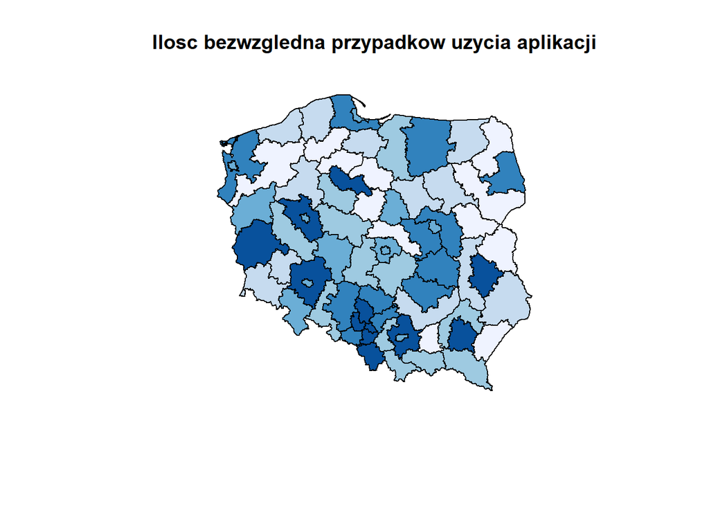

```r
map <- subset(eu_nuts, STAT_LEVL_ == 3)
lon_lat <- data.frame(lon = session$lon, lat = session$lat)

coord2nuts <- function(lon_lat) {
  coordinates(lon_lat) <- ~ lon + lat
  proj4string(lon_lat) <- CRS("+init=epsg:4326")
  map@proj4string <- lon_lat@proj4string
  rt <- over(lon_lat, map)
  return(rt)
}
session$nuts3 <- coord2nuts(lon_lat)$NUTS_ID
freq <- data.frame(table(session$nuts3))
freq <- freq[grepl("PL", freq$Var1),]
colnames(freq) <- c("NUTS_ID", "FREQ")

map@data$NUTS_ID_char <- as.character(map@data$NUTS_ID)
map@data$country <- substr(map@data$NUTS_ID_char, 1, 2)
map <- map[map@data$country == "PL", ]

spatial_data <-
  merge(
    y = freq,
    x = map,
    by.y = "NUTS_ID",
    by.x = "NUTS_ID",
    sort = FALSE,
    all.x = F
  )

colors <- brewer.pal(6, "Blues")
brks <- classIntervals(spatial_data$FREQ, 6)
brks <- brks$brks
plot(spatial_data,
     col = colors[findInterval(spatial_data$FREQ, brks, all.inside = TRUE)],
     axes = F,
     main = "Ilosc bezwzgledna przypadkow uzycia aplikacji")
```

Uzytkownikow firmy mozna podzielic na poszczegolne podregiony NUTS3 w ktorych najczesciej uzywaja aplikacji.

Przykladowo, w wartosciach bewzglednym aplikacja jest uzywana rzadko w podregionie szczecinsko-pyrzyckim, z kolei jest uzywana czesto w regionie zielonogórskim.

Nie mowi to jeszcze nic o popularnosci aplikacji poniewaz nie bierzemy pod uwage populacji danych regionow.

Widoczny jest takze podzial na Polske pólnocna i poludniowa, na poludniu wiecej osob korzysta z aplikacji niz na polnocy.

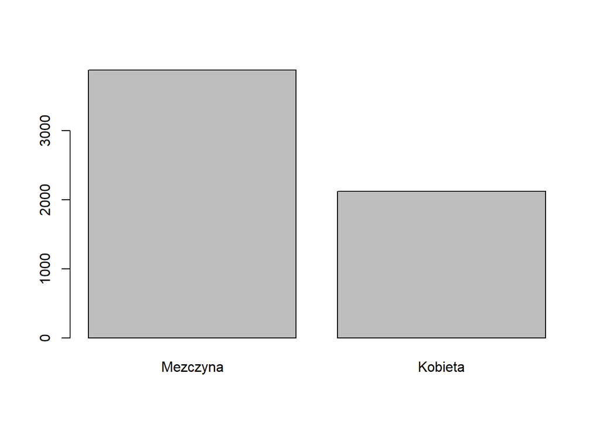

```r
barplot(table(klienci$plec), names.arg = c('Mezczyna', 'Kobieta'))
```

Na plcie, wsrod klientow jest wiecej mezczyzn niz kobiet, mimo tego kobiety kupuja wiecej uslug premium (patrz. Zad 7.)

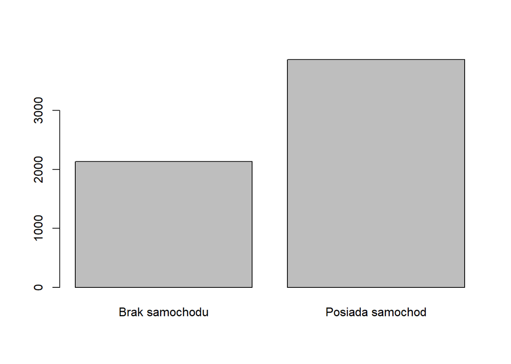

```r
barplot(table(klienci$czy_samochod),
        names.arg = c('Brak samochodu', 'Posiada samochod'))
```

Na fakt posiadania samochodow, wsrod klientow jest wiecej osob posiadajacych samochod.

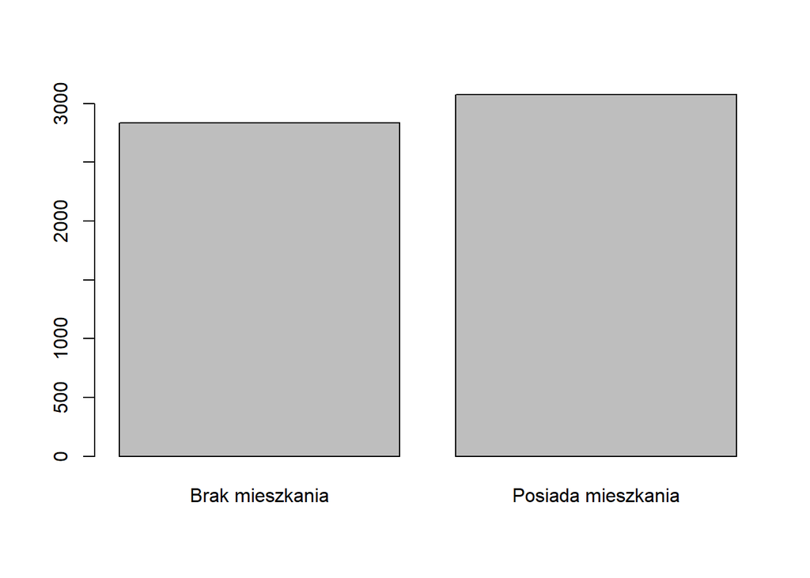

```r
barplot(table(klienci$czy_mieszkanie),
        names.arg = c('Brak mieszkania', 'Posiada mieszkania'))
```

Na fakt posiadania mieszkania, minimalnie wiecej osob posiada mieszkanie.

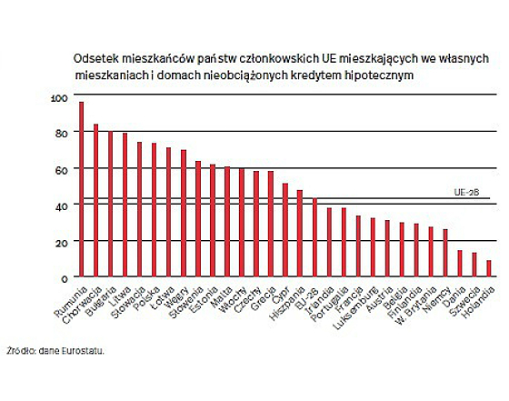

```r
knitr::include_graphics("mieszkania_wlasne.jpg")
```

W Polsce 73 proc. osób mieszka we własnych mieszkaniach, bez kredytu.

```r
mean(klienci$wiek[!is.na(klienci$wiek)])
```

```
## [1] 50.8732
```

```r
median(klienci$wiek[!is.na(klienci$wiek)])
```

```
## [1] 51
```

Sredni wiek/mediane wieku 50.9/51 lat klientow.

Nie mamy do czynienia z osobami mlodymi.

Zatem zaskakujaco duzo sposrod naszych klientow nie posiada mieszkania.

```r
quantile(klienci$wiek, na.rm = TRUE)
```

```
##   0%  25%  50%  75% 100%
##   18   47   51   55   73
```

25% klientow jest w wieku w wieku od 47 do 51 lat.

25% klientow jest w wieku w wieku od 51 do 55 lat.

25% klientow jest w wieku w wieku od 55 do 73 lat.

Aż 50% klientów jest w wieku od 47 do 55 lat.

Widac wiec ze bardzo wielu naszych klientow jest w poznych wieku srednim.

Srednia wynoi 51 lat i jest bardzo bliska mediany, nie ma wyraznej asymetrii rozkładu wieku klientow.

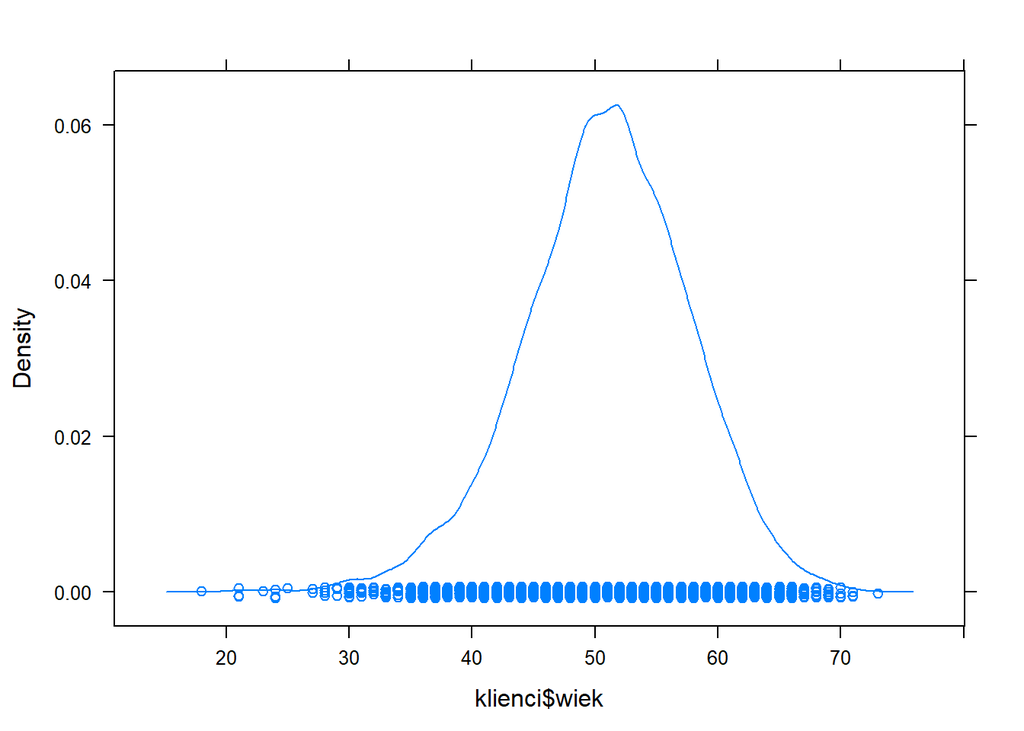

```r
densityplot(klienci$wiek)
```

### Zad 3. Czy model płatny trafia zgodnie z założeniami do wykształconej grupy odbiorców?

```r
table(klienci$wyksztalcenie[klienci$czy_kupil == 1])
```

```
##
## podstawowe    srednie     wyzsze
##        276        396        396
```

```r
mean(klienci$wiek[!is.na(klienci$wiek)])
```

```
## [1] 50.8732
```

```r
median(klienci$wiek[!is.na(klienci$wiek)])
```

```
## [1] 51
```

To czy model biznesowy trafia do osob wyksztalconych zalezy od struktury wyksztalcenia w populacji potencjalnych klinetow.

Nie ma ani jednej obserwacji z wyksztalceniem zasadniczym zawodowym, wiec trzeba byloby sie zastanowic czy jest ono kodowane jako podstawowe czy srednie razem z wyksztalceniem srednim zawodowym.

Zakladajac ze grupa potencjalnych klientow odzwierciedla populacje Polski i biorac pod uwage ze sredni wiek klientow wynosi 50,87 lat a mediana 51 lat to fakt, że w populacji klientow, ktorzy wykupili uslugi premium znajduje sie o ponad 40% wiecej osob z wyksztalceniem wyzszym niz podstawowym nalezy uznac za sukces gdyz w populacji Polski osoby w tym wieku kilkukrotnie czesciej maja wyksztalcenie zasadnicze zawodowe.

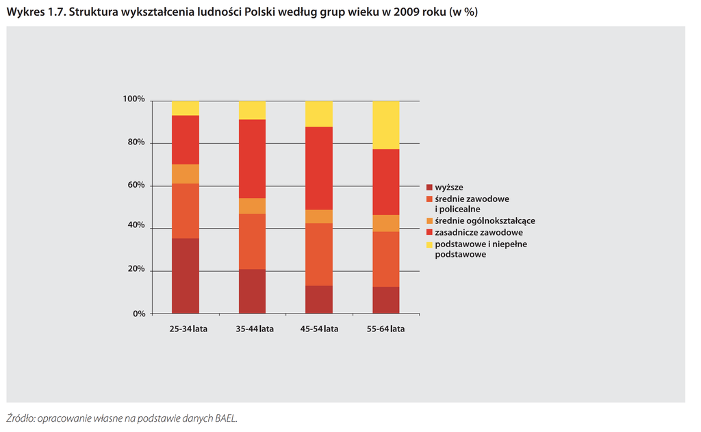

```r
knitr::include_graphics("wyksztalcenie.png")
```

Jezeli jednak model biznesowy uwzglednial kierowanie sie przede wszystkim do osob z wyksztalceniem wyzszym to należaloby sie zastanowic czy satysfakcjonuje nas fakt, że mamy dokladnie tyle samo klientow z wyksztalceniem srednim i wyzszym

### Zad 4. Czy zarobki użytkowników mają wpływ na częstotliwość korzystania z aplikacji i czas spędzany w apce?

```r
salary <-
  data.frame(klient_id = klienci$klient_id,
             wynagrodzenie = klienci$wynagrodzenie)


for (i in 1:length(salary$klient_id)) {
  salary$nsessions[i] <-
    sum(session_info$klient_id == salary$klient_id[i])
}

for (i in 1:length(salary$klient_id)) {
  salary$session_length_mean[i] <-
    mean(session_info$dlugosc_sesji_min[session_info$klient_id == salary$klient_id[i]])
  salary$session_length_median[i] <-
    median(session_info$dlugosc_sesji_min[session_info$klient_id == salary$klient_id[i]])
}


for (i in 1:length(salary$klient_id)) {
  salary$session_length_mean[i] <-
    mean(session_info$dlugosc_sesji_min[session_info$klient_id == salary$klient_id[i]])
  salary$session_length_median[i] <-
    median(session_info$dlugosc_sesji_min[session_info$klient_id == salary$klient_id[i]])
  salary$session_length_variance[i] <-
    var(session_info$dlugosc_sesji_min[session_info$klient_id == salary$klient_id[i]])
  salary$session_length_90percentile[i] <-
    quantile(session_info$dlugosc_sesji_min[session_info$klient_id == salary$klient_id[i]], 0.9)[[1]]
  salary$session_length_10percentile[i] <-
    quantile(session_info$dlugosc_sesji_min[session_info$klient_id == salary$klient_id[i]], 0.1)[[1]]
}


for (i in 1:length(salary$klient_id)) {
  dates <-
    session_info$date[session_info$klient_id == salary$klient_id[i]]
  dates <- dates[dates != "0"]
  dates <- dates[!is.na(dates)]
  dates <- as.Date(dates)
  salary$klient_ndays[i] <- as.numeric(today() - min(dates))
}

for (i in 1:length(salary$klient_id)) {
  dates <-
    session_info$date[session_info$klient_id == salary$klient_id[i]]
  dates <- dates[dates != "0"]
  dates <- dates[!is.na(dates)]
  dates <- as.Date(dates)
  salary$avg_diff_days[i] <- as.numeric(mean(diff(sort(dates))))
}

salary$klient_ndays <-
  salary$klient_ndays / min(salary$klient_ndays)
salary$nsessions_per_ndays <-
  salary$nsessions / salary$klient_ndays
salary$activity_frequency <-
  1 / (salary$avg_diff_days / min(salary$avg_diff_days))
```

Im czesciej klient korzysta z apliakcji tym sredni odstep miedzy uzyciami jest nizszy a im czesciej klient uzywa aplikacji tym lepszym jest dla nas klientem, stad odwrocenie.

```r
salary$nsessions_per_avgdifftime <-
  salary$nsessions * salary$activity_frequency
```

Jezeli sredni czas miedzy iloscia sesji jest krotki to jedna sesja klienta jest “warta” wiecej

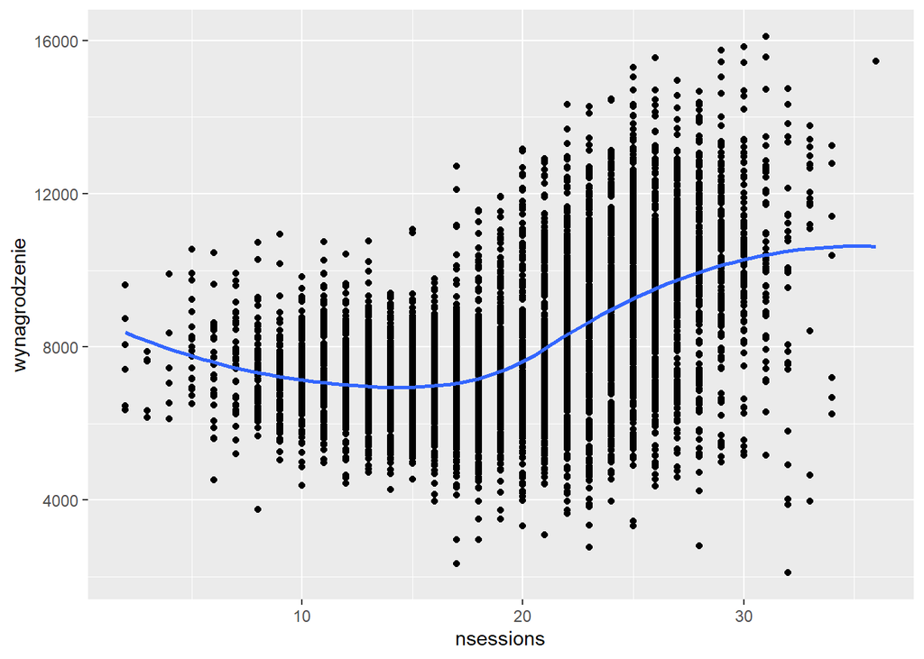

```r
salary$activity_overall <-
  log(salary$nsessions_per_avgdifftime * salary$nsessions_per_ndays)


ggplot(salary, aes(x = nsessions, y = wynagrodzenie)) + geom_point() + geom_smooth(method =
                                                                                     "loess", se = F)
```

Ciezko stwierdzic na ile parametr nsessions odzwierciedla czestosc korzystania z aplikacji bo jest on mocno zwiazany z tym od jak dawna dany klient jest naszym klientem. Widać jednak, że klienci z wieksza ilosci sesji sa też klientami nieco lepiej zarabiajacymi. Sepcjalnie nie usuwalem brakow danych w wynagrodzeniu po to zeby potem latwo zmergowac z glownym df i przeprowadzić imputacje brakow danych

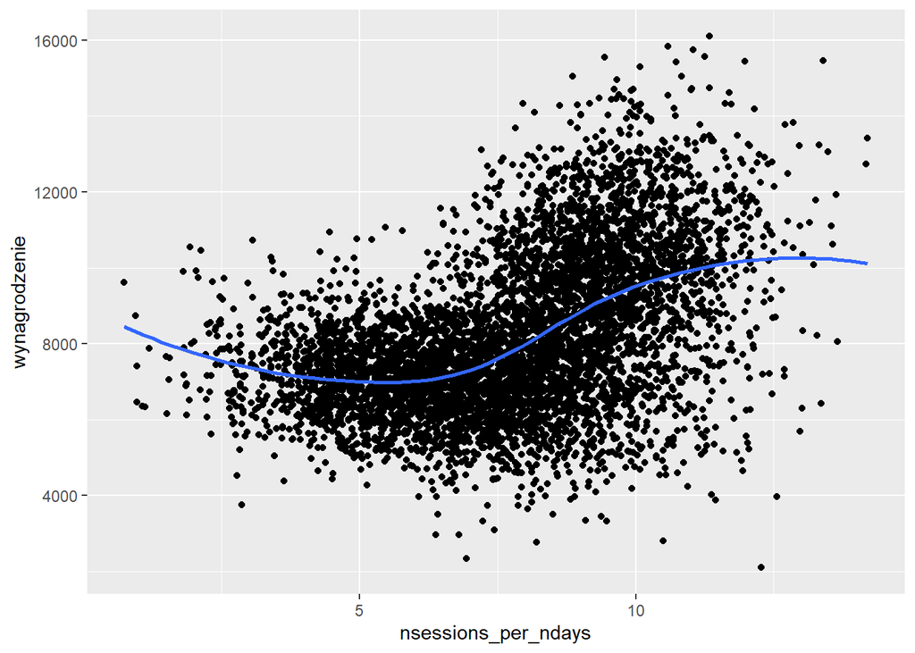

```r
ggplot(salary, aes(x = nsessions_per_ndays, y = wynagrodzenie)) + geom_point() + geom_smooth(method =
                                                                                               "loess", se = F)
```

Zmienna nsessions_per_ndays poza iloscia akcji jakich dokonal klient bierze pod uwage uplyw czasu od pierwszej akcji jakiej dokonal klient czyli to jak dlugo jest naszym klientem. Widać, że klienci z wyzszym wynagrodzeniem sa bardziej aktywni w naszej aplikacji jednak nalezy zwrocic uwage na to, ze wariancja jest wysoka

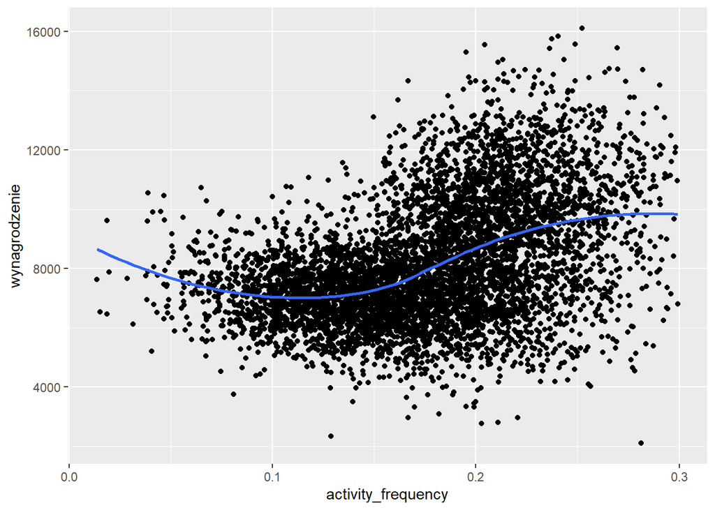

```r
temp <- salary %>% filter(activity_frequency < 0.3)
ggplot(temp, aes(x = activity_frequency, y = wynagrodzenie)) + geom_point() + geom_smooth(method = "loess", se = F)
```

Osoby czesto korzystajace z aplikacji (majace bardzo niska srednio roznice w dniach miedzy jednym a nastepnym uzyciem aplikacji) maja wyzsze wynagrodzenie

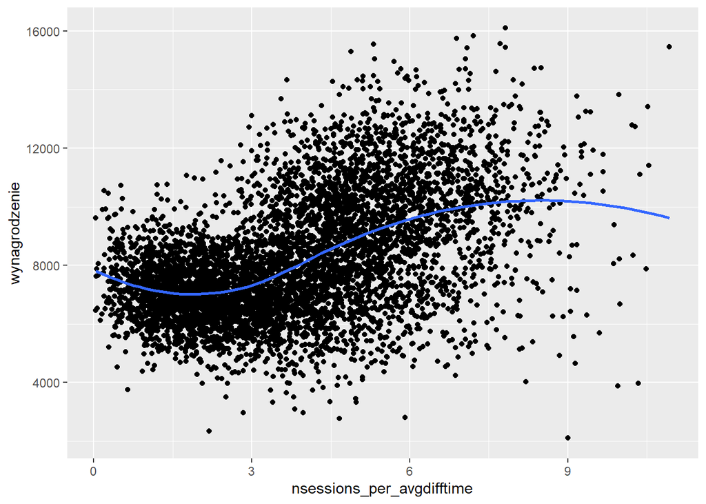

```r
ggplot(salary, aes(x = nsessions_per_avgdifftime, y = wynagrodzenie)) + geom_point() + geom_smooth(method =
                                                                                                     "loess", se = F)
```

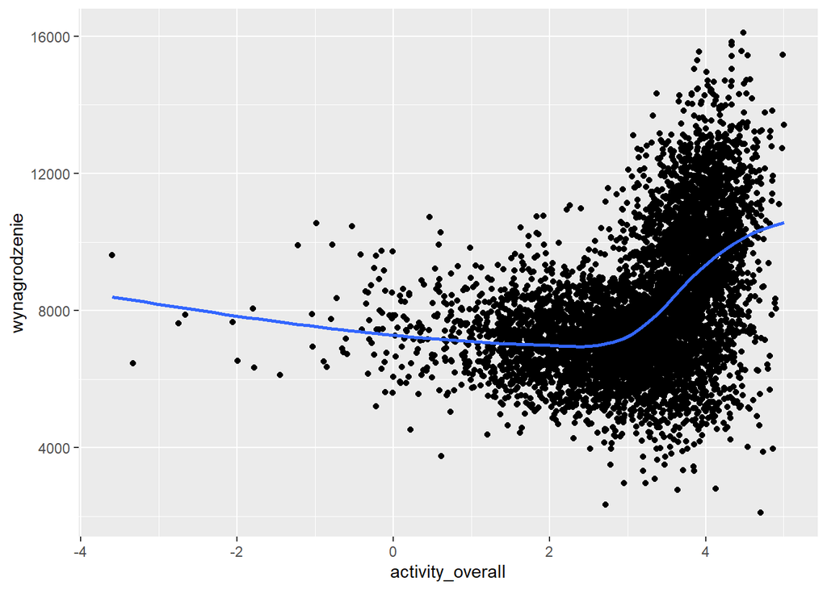

```r
ggplot(salary, aes(x = activity_overall, y = wynagrodzenie)) + geom_point() + geom_smooth(method = "loess", se = F)
```

```r
model <- lm(activity_overall ~ wynagrodzenie, data = salary)
summary(model)
```

```
##
## Call:
## lm(formula = activity_overall ~ wynagrodzenie, data = salary)
##
## Residuals:
##     Min      1Q  Median      3Q     Max
## -7.0437 -0.4163  0.1515  0.5957  2.7371
##
## Coefficients:
##                Estimate Std. Error t value Pr(>|t|)
## (Intercept)   1.554e+00  4.832e-02   32.16   <2e-16 ***
## wynagrodzenie 1.970e-04  5.720e-06   34.44   <2e-16 ***
## ---
## Signif. codes:  0 '***' 0.001 '**' 0.01 '*' 0.05 '.' 0.1 ' ' 1
##
## Residual standard error: 0.9076 on 5878 degrees of freedom
##   (120 observations deleted due to missingness)
## Multiple R-squared:  0.1679, Adjusted R-squared:  0.1678
## F-statistic:  1186 on 1 and 5878 DF,  p-value: < 2.2e-16
```

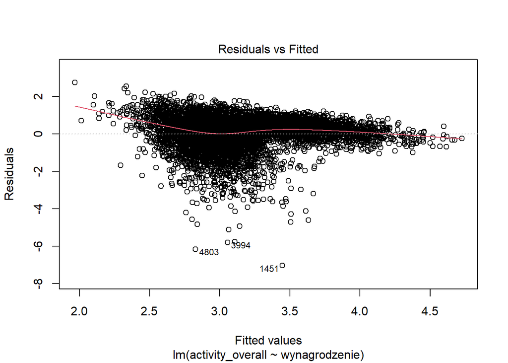

```r
plot(model, which = 1)
```

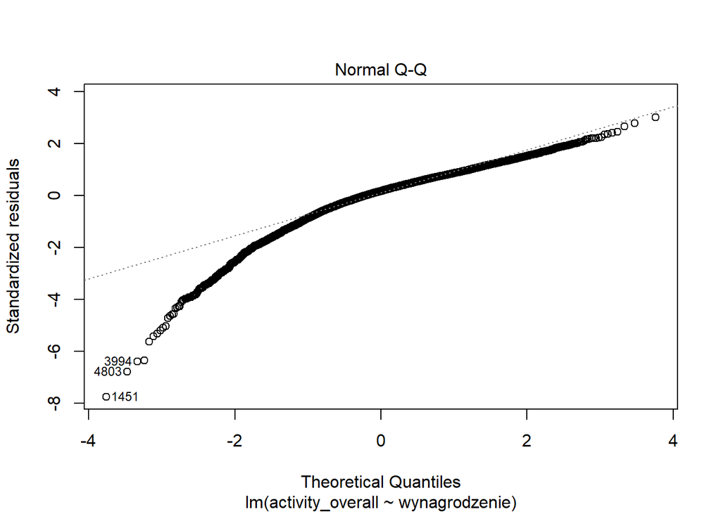

```r
plot(model, which = 2)
```

Obserwacje odstajace na pierwszych kwantylach

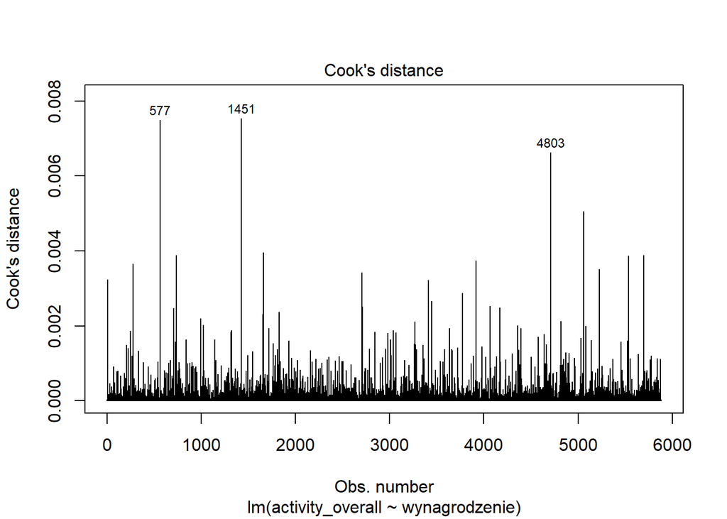

```r
plot(model, which = 4)
```

Jest kilka outlierow, zmiany wartoci wspóczynników regresji przy pominiciu tych obserwacji nie przekraczaja 0.1

```r
bptest(model)
```

```
##
##  studentized Breusch-Pagan test
##
## data:  model
## BP = 93.92, df = 1, p-value < 2.2e-16
```

Na kazdym realistycznym poziomie istotnosci odrzucamy H0 o stabilnosci wariancji skladnika losowego

Charakter tej zaleznosci w lepszym stopniu oddaje regresja ważona lokalnie (loess) widoczna na wykresach niz regresja liniowa.

Podsumowywujac - tak, istnieje zaleznosc miedzy zarobkami klientow a czestotliowoscia uzywania aplikacji i jest ona widoczna na wykresach (tj. osoby ponadprzecietnie czesto korzystajace z aplikacji sa zazwyczaj osobami ponadprzecietnei zarabiajacymi)

Wariancja jest dosyc wysoka i jest duże grono osób ponadprzecietnie zarabiajacych i nieróżniacych sie od osob biedniejszych pod katem czestotliwosci uzywania aplikacji.

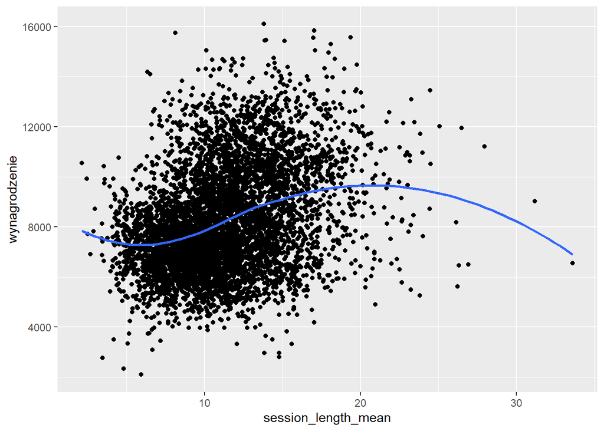

```r
ggplot(salary, aes(x = session_length_mean, y = wynagrodzenie)) + geom_point() + geom_smooth(method = "loess", se = F)
```

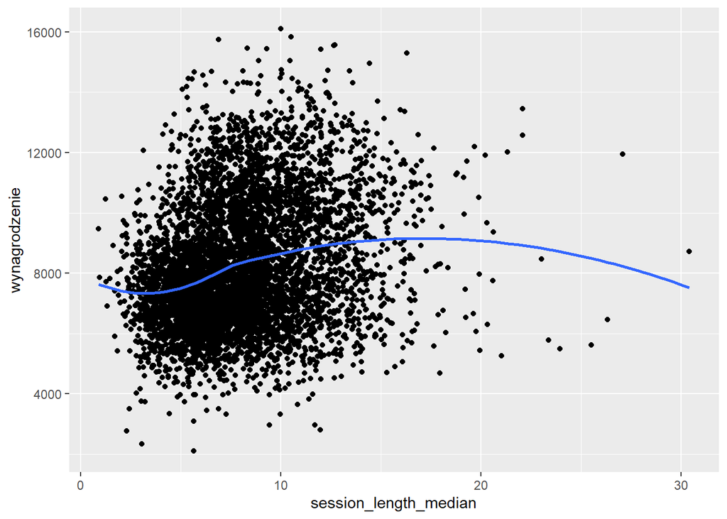

```r
ggplot(salary, aes(x = session_length_median, y = wynagrodzenie)) + geom_point() + geom_smooth(method = "loess", se = F)
```

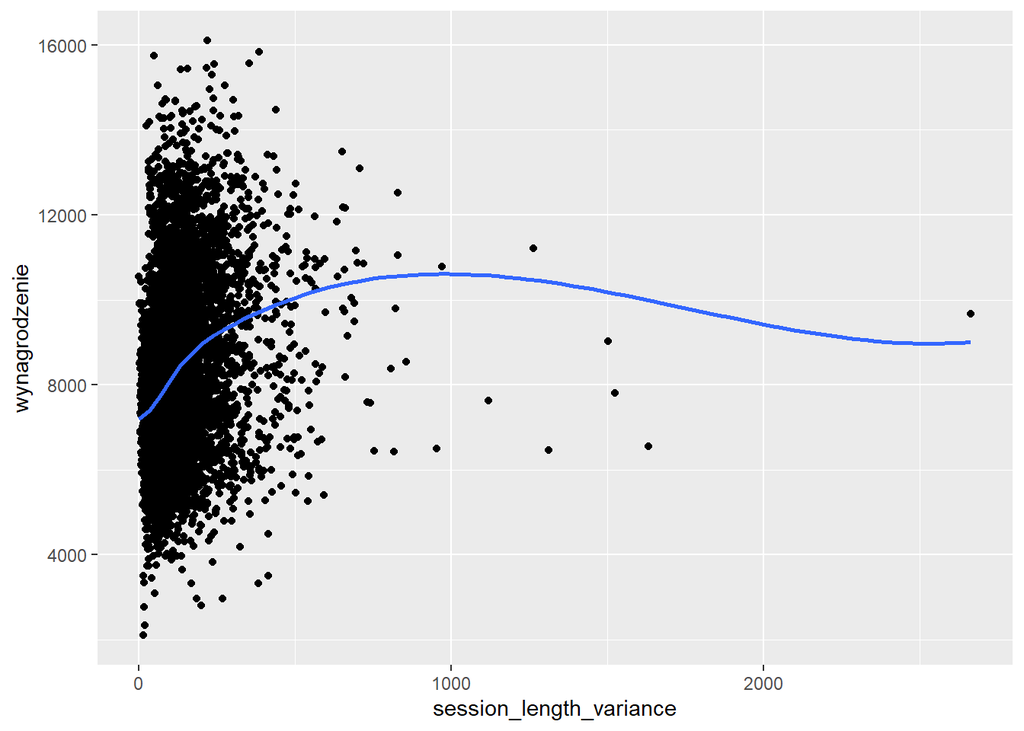

```r
ggplot(salary, aes(x = session_length_variance, y = wynagrodzenie)) + geom_point() + geom_smooth(method = "loess", se = F)
```

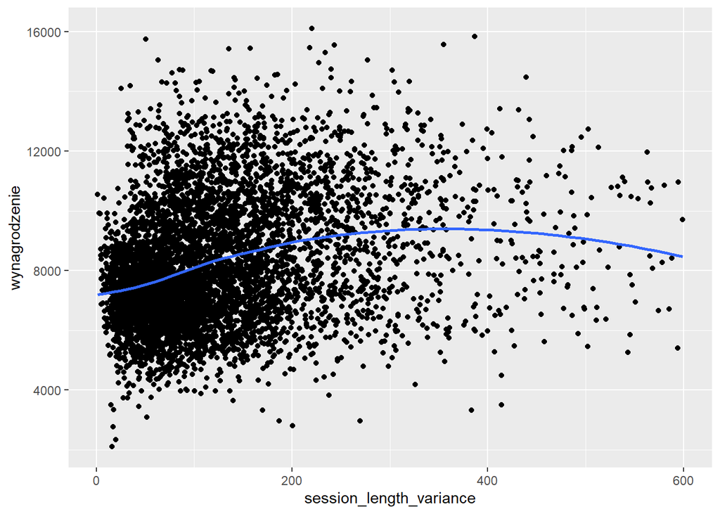

```r
temp <- salary %>% filter(session_length_variance < 600)
ggplot(temp, aes(x = session_length_variance, y = wynagrodzenie)) + geom_point() + geom_smooth(method = "loess", se = F)
```

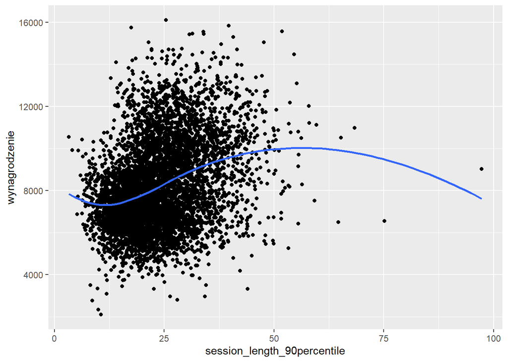

```r
ggplot(salary, aes(x = session_length_90percentile, y = wynagrodzenie)) + geom_point() + geom_smooth(method = "loess", se = F)
```

### Zad 5. W jakich regionach kraju aplikacja nie jest jeszcze zbyt popularna?

```r
poland_nuts3_population <- vroom("poland_nuts3_population.csv")
```

```
## Rows: 264
## Columns: 6
## chr [5]: GEO, UNIT, LANDUSE, Value, Flag and Footnotes
## dbl [1]: TIME
##
## Pass a specification to the `col_types` argument to quiet this message
```

```r
poland_nuts3_population <-
  poland_nuts3_population[poland_nuts3_population$TIME == 2013,]

poland_pop <-
  data.frame(NUTS_ID = poland_nuts3_population$GEO, POP = poland_nuts3_population$Value)

poland_pop$POP <- as.numeric(gsub(",", "", poland_pop$POP))
```

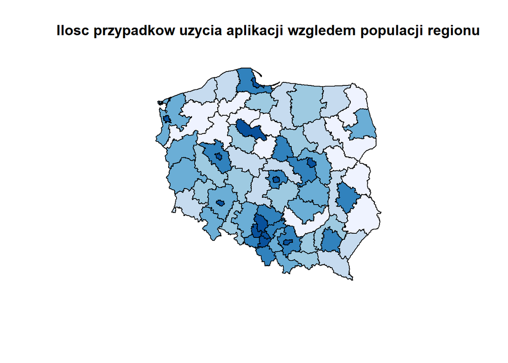

```r
freq <- freq %>% left_join(poland_pop, by = "NUTS_ID")
freq$FREQ_PER_POP <- freq$FREQ / freq$POP

spatial_data <-
  merge(
    y = freq,
    x = map,
    by.y = "NUTS_ID",
    by.x = "NUTS_ID",
    sort = FALSE,
    all.x = F
  )

colors <- brewer.pal(6, "Blues")
brks <- classIntervals(spatial_data$FREQ_PER_POP, 6)
brks <- brks$brks
plot(spatial_data,
     col = colors[findInterval(spatial_data$FREQ_PER_POP, brks, all.inside = TRUE)],
     axes = F,
     main = "Ilosc przypadkow uzycia aplikacji wzgledem populacji regionu")
```

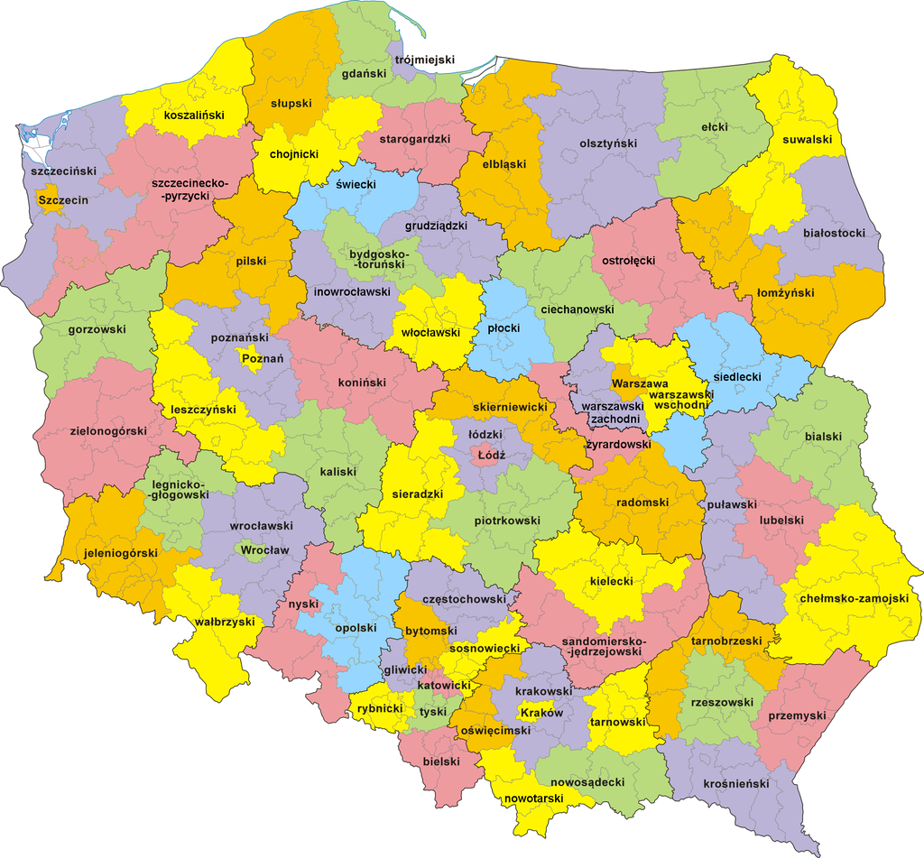

```r
knitr::include_graphics("regiony_nuts3.png", )
```

Aplikacja nie jest jeszcze zbyt popularna w regionach takich jak:

-szczecinsko-przycyki

-pilski

-chojnicki

-swiecki

-grudziacki

-wloclawski

-suwalski

-lomzynski

-siedlecki

-bialski

-chelmsko-zamojski

-sandomiersko-jedrzejowski

### Zad 6. Jak przyrastała nam liczba użytkowników w czasie? Czy było jakieś wydarzenie, które miało wpływ na liczbę użytkowników?

```r
for (i in 1:length(klienci$klient_id)) {
  dates <-
    session_info$date[session_info$klient_id == klienci$klient_id[i]]
  dates <- dates[dates != "0"]
  dates <- dates[!is.na(dates)]
  dates <- as.Date(dates)
  klienci$first_day[i] <- min(dates)
}
```

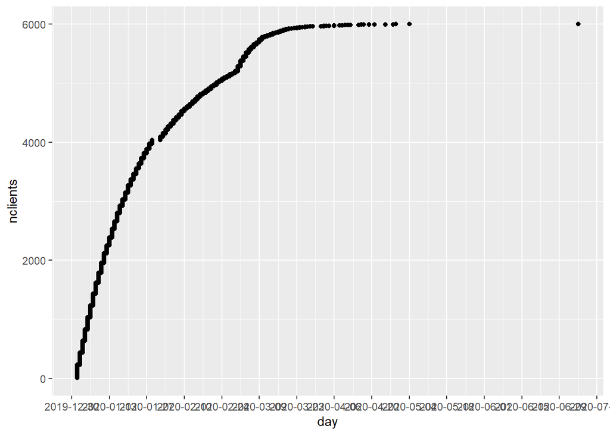

```r
klienci_ordered <- klienci[order(klienci$first_day),]
klienci_ordered$nclients <- seq(1,length(klienci_ordered$klient_id),by=1)
klienci_ordered$day <- as.Date(klienci_ordered$first_day)

ggplot(klienci_ordered, aes(x = day, y = nclients)) + geom_point() + scale_x_date(breaks = "2 weeks")
```

Pierwszy na przelomie stycznia i lutego -> nastepuje spowolnienie tempa pozyskiwania nowych uzytkonwnikow, które trwa przez caly luty

Drugi na przelomie lutego i marca -> nastepuje przyspieszenie tempa pozyskiwania nowych uzytkownikow

### Zad 7. Jakie rodzaje segmentów użytkowników aplikacji posiadamy? Które segmenty częściej sięgają po usługę premium

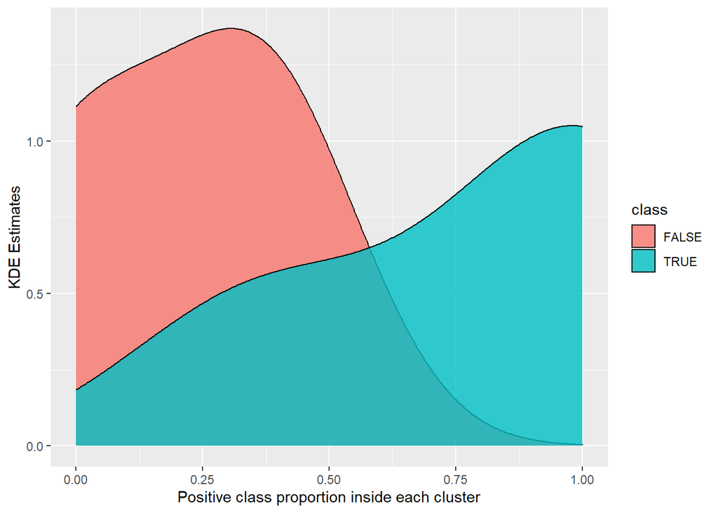

```r
klienci_clustering <- klienci
klienci_clustering$first_day <- c()
onehotmatrix <- model.matrix(object = czy_kupil ~ . - 1, data = klienci_clustering)
source("PlotDbscanClustering.R")
PlotDbscanClustering(onehotmatrix,'plec')
```

Model Dbscan sie bardzo mocno przetrenowywuje ze wzgledu na mala ilosc danych, zrobiony glownie pod wizualizacje

```r
table(klienci$czy_kupil[klienci$plec == 0])
```

```
##
##    0    1
## 3449  431
```

```r
table(klienci$czy_kupil[klienci$plec == 1])
```

```
##
##    0    1
## 1483  637
```

Kobiety relatywnie czesciej kupuja uslugi premium, segment plec ma znaczenie, mimo ze jest ich w populacji mniej to jest wiecej przypadkow kupna przez kobiety

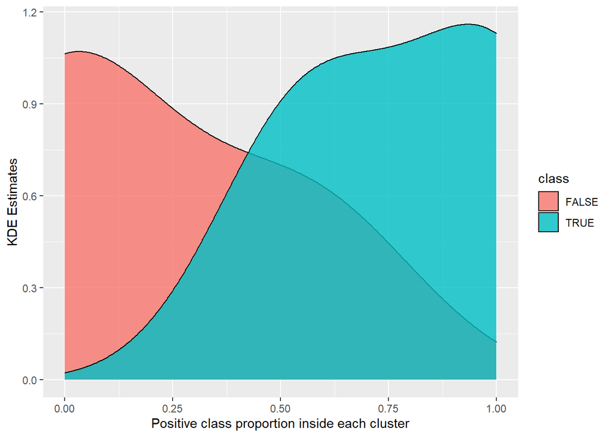

```r
PlotDbscanClustering(onehotmatrix,'czy_mieszkanie')
```

```r
table(klienci$czy_kupil[klienci$czy_mieszkanie == 0])
```

```
##
##    0    1
## 2402  432
```

```r
table(klienci$czy_kupil[klienci$czy_mieszkanie == 1])
```

```
##
##    0    1
## 2459  617
```

Osoby z mieszkaniem nieco czesciej kupuja uslugi premium

```r
quantile(klienci$wiek, na.rm = TRUE)
```

```
##   0%  25%  50%  75% 100%
##   18   47   51   55   73
```

```r
table(klienci$czy_kupil[klienci$wiek < 47])
```

```
##
##   0   1
## 993 423
```

```r
table(klienci$czy_kupil[!klienci$wiek < 47])
```

```
##
##    0    1
## 3794  610
```

Osoby w wieku mlodszym niz 47 lat kupuja czesciej uslugi premium niz pozostali

```r
table(klienci$czy_kupil[klienci$wiek > 47 & klienci$wiek < 51])
```

```
##
##   0   1
## 882 157
```

```r
table(klienci$czy_kupil[!klienci$wiek > 47 & klienci$wiek < 51])
```

```
##
##    0    1
## 1215  456
```

Osoby miedzy 47 a 51 rokiem zycia kupuja rzadziej uslugi premium niz pozostali

```r
table(klienci$czy_kupil[klienci$wiek > 51 & klienci$wiek < 55])
```

```
##
##   0   1
## 905 132
```

```r
table(klienci$czy_kupil[!klienci$wiek > 51 & klienci$wiek < 55])
```

```
##
##    0    1
## 2377  660
```

Osoby miedzy 51 a 55 rokiem zycia kupuja nieco rzadziej uslugi premium niz pozostali

```r
table(klienci$czy_kupil[klienci$wiek > 55 & klienci$wiek < 73])
```

```
##
##    0    1
## 1235  201
```

```r
table(klienci$czy_kupil[!klienci$wiek > 55 & klienci$wiek < 73])
```

```
##
##    0    1
## 3551  832
```

Osoby miedzy 55 a 73 rokiem zycia kupuja nieco rzadziej uslugi premium niz pozostali

Ze wzgledu na wynagrodzenie

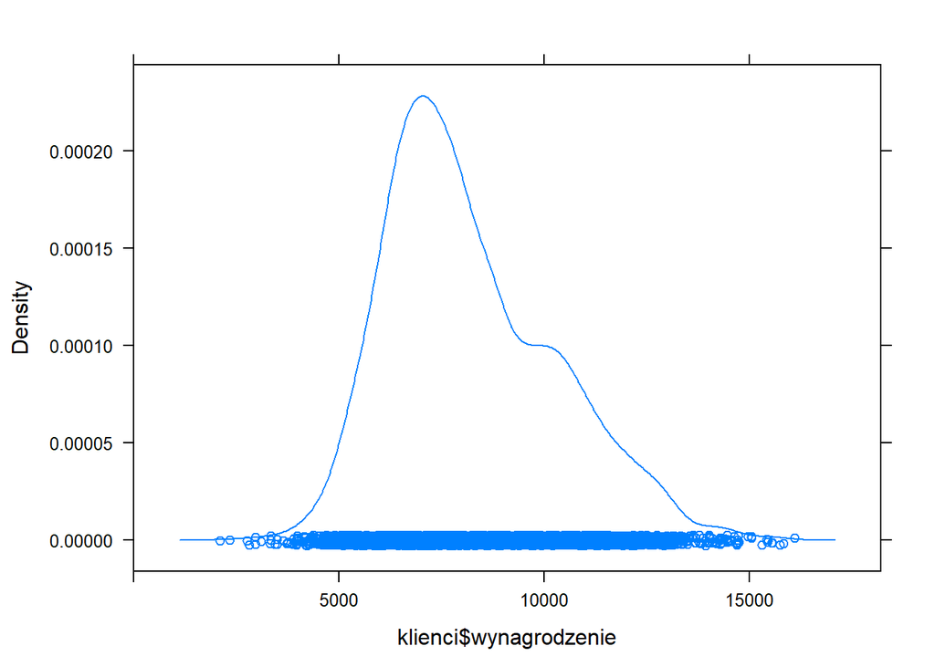

```r
densityplot(klienci$wynagrodzenie)
```

Delikatna prawostronna asymetria rozkadu wynagrodzen

```r
quantile(klienci$wynagrodzenie, na.rm = TRUE)
```

```
##      0%     25%     50%     75%    100%
##  2100.0  6677.5  7793.0  9546.5 16100.0
```

```r
table(klienci$czy_kupil[klienci$wynagrodzenie < 6677.5])
```

```
##
##    0    1
## 1112  358
```

```r
table(klienci$czy_kupil[!klienci$wynagrodzenie < 6677.5])
```

```
##
##    0    1
## 3724  686
```

Osoby z wynagrodzeniem poniżej 6677.5 (pierwszy kwartyl) czesciej kupuja uslugi premium niz pozostali

```r
table(klienci$czy_kupil[klienci$wynagrodzenie > 6677.5 & klienci$wynagrodzenie < 7793])
```

```
##
##    0    1
## 1193  276
```

```r
table(klienci$czy_kupil[!klienci$wynagrodzenie > 6677.5 & klienci$wynagrodzenie < 7793])
```

```
##
##    0    1
## 1112  358
```

```r
table(klienci$czy_kupil[klienci$wynagrodzenie > 7793.0 & klienci$wynagrodzenie < 9546.5])
```

```
##
##    0    1
## 1218  251
```

```r
table(klienci$czy_kupil[!klienci$wynagrodzenie > 7793.0 & klienci$wynagrodzenie < 9546.5])
```

```
##
##    0    1
## 2306  635
```

Osoby z wynagrodzeniem miedzy 7793 a 9546.5 nieco rzadziej kupuja uslugi premium niz pozostali

```r
table(klienci$czy_kupil[klienci$wynagrodzenie > 9546.5])
```

```
##
##    0    1
## 1312  158
```

```r
table(klienci$czy_kupil[!klienci$wynagrodzenie > 9546.5])
```

```
##
##    0    1
## 3524  886
```

Osoby z wynagrodzeniem powyzej 9546.5 nieco rzadziej kupuja uslugi premium niz pozostali

Ciekawa zaleznosc -> osoby najmniej zarabiajace najczesciej kupuja uslugi premium

### Zad 8. Czy klienci korzystają z aplikacji w jednym miejscu, czy może w większej liczbie miejsc? Jaki jest średni rozrzut odległości w wykorzystaniu aplikacji?

```r
for (i in 1:length(klienci$klient_id)) {
  klienci$nloc[i] <-
    length(unique(session[session$klient_id == klienci$klient_id[i], ]$nuts3))
}
```

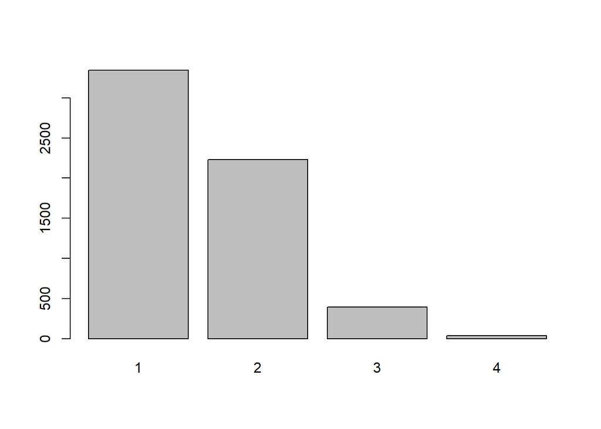

```r
barplot(table(klienci$nloc))
```

```r
table(klienci$nloc)
```

```
##
##    1    2    3    4
## 3344 2229  392   35
```

```r
(392 + 35) / (3344 + 2229 + 392 + 35)
```

```
## [1] 0.07116667
```

```r
for (i in 1:length(klienci$klient_id)) {
max_session <- session[session$klient_id == klienci$klient_id[i],][which.min(unique(session[session$klient_id == klienci$klient_id[i],])$lon + unique(session[session$klient_id == klienci$klient_id[i],])$lat), ]
min_session <- session[session$klient_id == klienci$klient_id[i],][which.max(unique(session[session$klient_id == klienci$klient_id[i],])$lon + unique(session[session$klient_id == klienci$klient_id[i],])$lat), ]

klienci$max_min_dist[i] <- distm(c(min_session$lon,min_session$lat), c(max_session$lon,max_session$lat))
}
mean(klienci$max_min_dist)
```

```
## [1] 14349.38
```

Sredni rozrzut odlegosci w wykorzystaniu aplikacji przez klientow to 14349 m

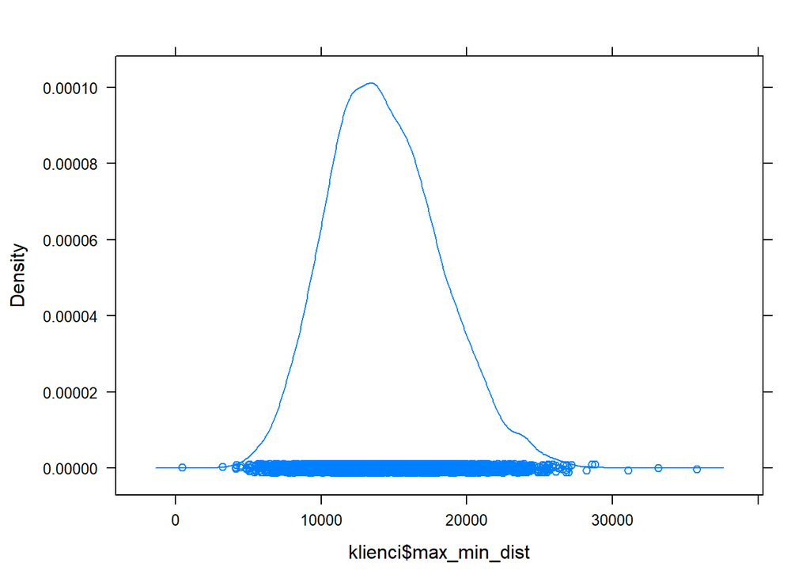

```r
densityplot(klienci$max_min_dist)
```

Brak wyraznej asymetrii rozkladu rozrzutu odlegosci w wykorzystaniu aplikacji przez klientow